# ReproImage report

12 images · 18 related pairs · ReproImage 0.1.0, algorithm version 1 · thresholds {"dhash": 10, "phash": 10}

**Requires expert review.** These are visual relations between images, not evidence of misconduct. A similar pair may be a legitimate reuse, a control shown twice, or an error.

## Related pairs

### Visually similar

orientation identity, dHash distance 1, pHash distance 4

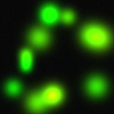

cells_a.png

cells_a_16bit.png

### Visually similar

orientation identity, dHash distance 1, pHash distance 4

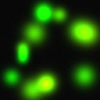

cells_a.png

cells_a_16bit.tif

### Identical pixels, different files

cells_a_16bit.png

cells_a_16bit.tif

### Identical pixels, different files

gel_a.png

gel_a.tif

### Visually similar

orientation identity, dHash distance 2, pHash distance 0

gel_a.png

gel_a_contrast.png

### Identical files

gel_a.png

gel_a_copy.png

### Visually similar

orientation flip, dHash distance 0, pHash distance 0

gel_a.png

gel_a_flip.png

### Visually similar

orientation rot270, dHash distance 0, pHash distance 0

gel_a.png

gel_a_rot90.png

### Visually similar

orientation identity, dHash distance 2, pHash distance 0

gel_a.tif

gel_a_contrast.png

### Identical pixels, different files

gel_a.tif

gel_a_copy.png

### Visually similar

orientation flip, dHash distance 0, pHash distance 0

gel_a.tif

gel_a_flip.png

### Visually similar

orientation rot270, dHash distance 0, pHash distance 0

gel_a.tif

gel_a_rot90.png

### Visually similar

orientation identity, dHash distance 2, pHash distance 0

gel_a_contrast.png

gel_a_copy.png

### Visually similar

orientation flip, dHash distance 2, pHash distance 0

gel_a_contrast.png

gel_a_flip.png

### Visually similar

orientation rot270, dHash distance 2, pHash distance 0

gel_a_contrast.png

gel_a_rot90.png

### Visually similar

orientation flip, dHash distance 0, pHash distance 0

gel_a_copy.png

gel_a_flip.png

### Visually similar

orientation rot270, dHash distance 0, pHash distance 0

gel_a_copy.png

gel_a_rot90.png

### Visually similar

orientation flip_rot90, dHash distance 0, pHash distance 0

gel_a_flip.png

gel_a_rot90.png

## Images

| File | Size | Format | Software | SHA-256 | dHash |
| --- | --- | --- | --- | --- | --- |
| cells_a.png | 128×128 | PNG, 8-bit |  | `329943cea349e350…` | `f0e2e6c6c6b6b2e2` |
| cells_a_16bit.png | 128×128 | PNG, 16-bit |  | `4dba668eb950a840…` | `f0e2e6c6c6b6b6e2` |
| cells_a_16bit.tif | 128×128 | TIFF, 16-bit |  | `69b51de8ca41a9a0…` | `f0e2e6c6c6b6b6e2` |
| cells_b.png | 128×128 | PNG, 8-bit |  | `ea4fda39e172abef…` | `f978ece37e1e0646` |
| gel_a.png | 128×128 | PNG, 8-bit |  | `2f99255aa83860f6…` | `eedcfc243aa84343` |
| gel_a.tif | 128×128 | TIFF, 8-bit |  | `5034d93aa5920765…` | `eedcfc243aa84343` |
| gel_a_contrast.png | 128×128 | PNG, 8-bit |  | `2f0fc99540b4f0b1…` | `eedcfc243aac4303` |
| gel_a_copy.png | 128×128 | PNG, 8-bit |  | `2f99255aa83860f6…` | `eedcfc243aa84343` |
| gel_a_flip.png | 128×128 | PNG, 8-bit |  | `89eaa897b9539841…` | `8cc4c0dba3ea3c3b` |
| gel_a_rot90.png | 128×128 | PNG, 8-bit |  | `764a777e92875b30…` | `2ba92d8d25ae2c35` |
| gel_a_spliced.png | 128×128 | PNG, 8-bit |  | `699e5ed4577acabc…` | `eec4fc283aa4535b` |
| gel_b.png | 128×128 | PNG, 8-bit |  | `fecc5357e31b875c…` | `3a17da38bad4e5aa` |